# HU12_lines_report

dblodgett@usgs.gov

11/9/2017

The WBD has many HU12s that have many contributing HU12s. There are three categories that these HU12s fall into:

**1) contributing HUs combine as they flow into the HU**

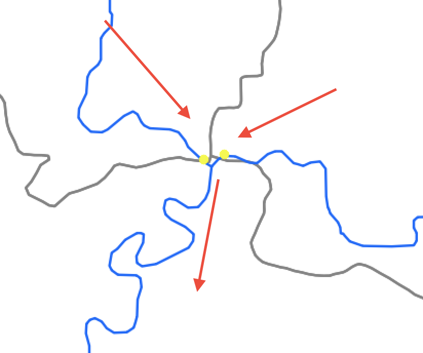

**2) contributing HUs combine at or very near the outlet of the HU**

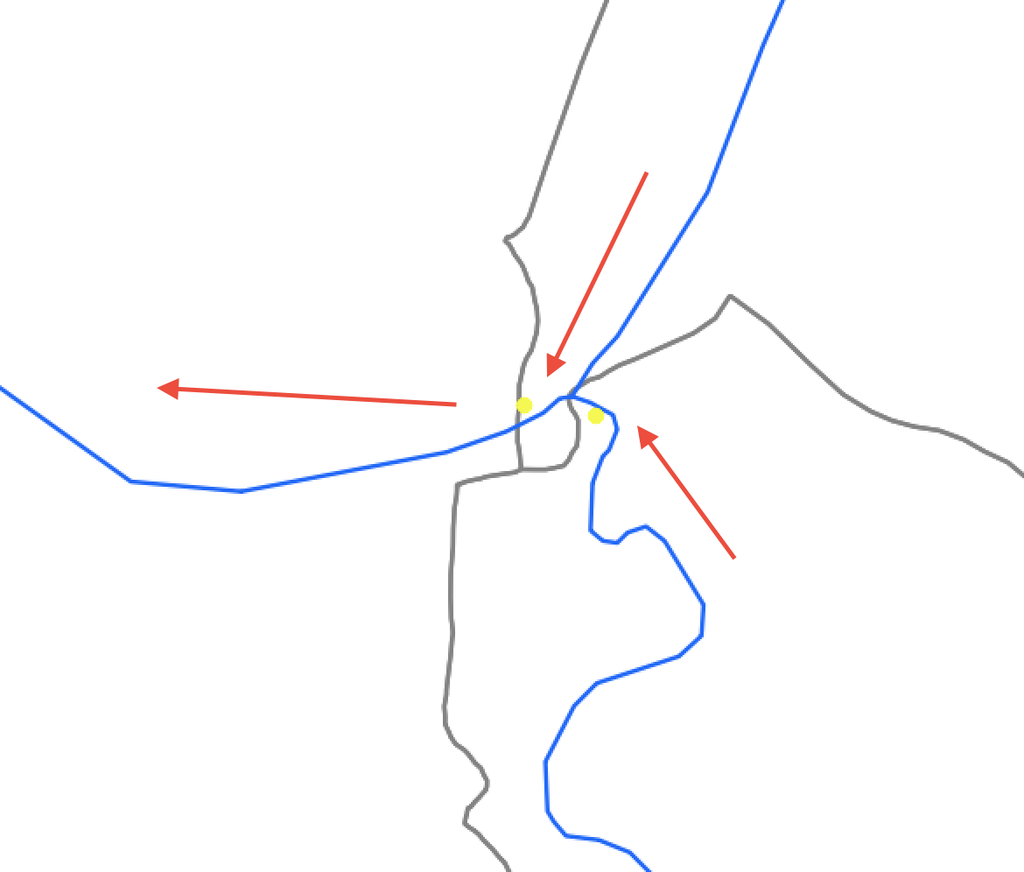

**3) contributing HUs combine somewhere in the HU**

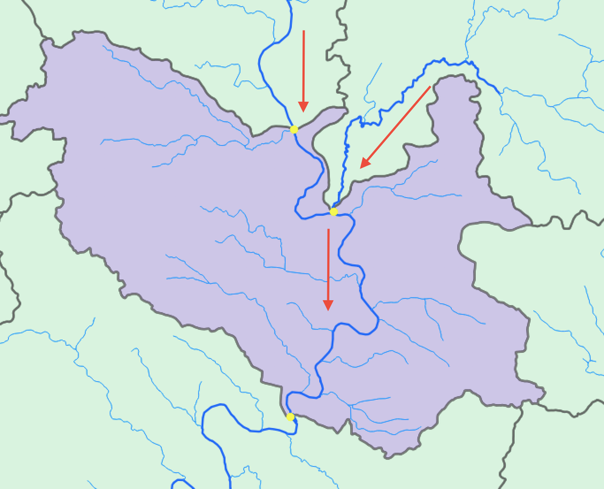

This analysis takes a critical look at these three categories using the from pour point “fpp” dataset to make sense of how HU12s combine.

The goal is to model HU12s as catchments. That is, as units with one inflow “nexus” (or node in NHDPlus terminology) and one outflow nexus where all unit combinations occur at nexuses.

The first case above is a simple confluence and is exactly how we want HUs to combine.

The second case above is a complex confluence that we will need to take a closer look at. While the geometry of the WBD and the HU_12_DS coding implies that the three watersheds highlighted in case 2 are chained, the two upstream watersheds should actually both flow directle into the downstream watershed. The following blocks of code illustrate a way to find these cases and update the HU_12_DS coding to “fix” the issue.

See comments in the following code for a description. Mostly this just loads the NHDPlusV2 WBD HU12 attributes to make sure we have the right set to join to later and prepares the fpp dataset for further analysis.

```r
hu_atts <- select(readRDS("hu12_atts.rds"), HUC12, HU_12_D)

# Found a few HUCs that feed to themselves. These are where they should go.
hu_fixes <- data.frame(HUC_12 = c("101800100703", "060101051402", "160300020305",
                               "170401050304", "101800110901", "101800120602",
                               "100200070304", "060101051302"),
                    HU_12_DS_f = c("101800100702", "060101051404", "160300020306",
                                 "170401050306", "101800110902", "101800120603",
                                 "100200070307", "060101051303"), stringsAsFactors = F)

# read fpps, transform to equal distance proj, remove duplicates, join to WBD attributes, apply fixes.
fpp <- sf::read_sf("fpp_data/fpp.shp", stringsAsFactors = F) %>%
  select(HUC_12, ISSINK) %>%
  sf::st_transform("+proj=eqdc +lat_0=39 +lon_0=-96 +lat_1=33 +lat_2=45 +x_0=0 +y_0=0 +datum=NAD83 +units=m +no_defs") %>%
  filter(!duplicated(HUC_12)) %>% #naive but ok.
  left_join(select(hu_atts, HUC12, HU_12_D), by = c("HUC_12" = "HUC12")) %>%
  rename(HU_12_DS = HU_12_D) %>%
  left_join(hu_fixes, by = "HUC_12") %>%
  mutate(HU_12_DS = ifelse(is.na(HU_12_DS_f), HU_12_DS, HU_12_DS_f)) %>%
  select(-HU_12_DS_f)

# Add X/Y position for calculations.
fpp <- bind_cols(fpp, as.data.frame(setNames(st_coordinates(fpp), c("X", "Y"))))
fpp_base_ds <- select(fpp, HUC_12, HU_12_DS, X, Y)
st_geometry(fpp_base_ds) <- NULL
fpp_base <- select(fpp_base_ds, HUC_12, X, Y)

names(hu_atts)
```

```
## [1] "HUC12"   "HU_12_D"
```

```r
names(fpp_base)
```

```
## [1] "HUC_12" "X"      "Y"
```

```r
names(fpp_base_ds)
```

```
## [1] "HUC_12"   "HU_12_DS" "X"        "Y"
```

There are two functions that are not shown here. One, `fg_to_lines` converts the fpp geometry (fg) into lines connecting the fpp according to the HU_12_DS attribute. The other, `collapse_fpp` adjusts the HU_12_DS for pairs of fpps that are under a specified threshold distance away from each other.

For the first pass, we just run `fg_to_lines` and look at the distribution of distance between connected fpps. This creates a `data.frame` called `sf_lines` (sf for simple features) and updates the `fg` `data.frame`. Note that this creates the `huc_lines.shp` file which can be used to visualize the result of this operation.

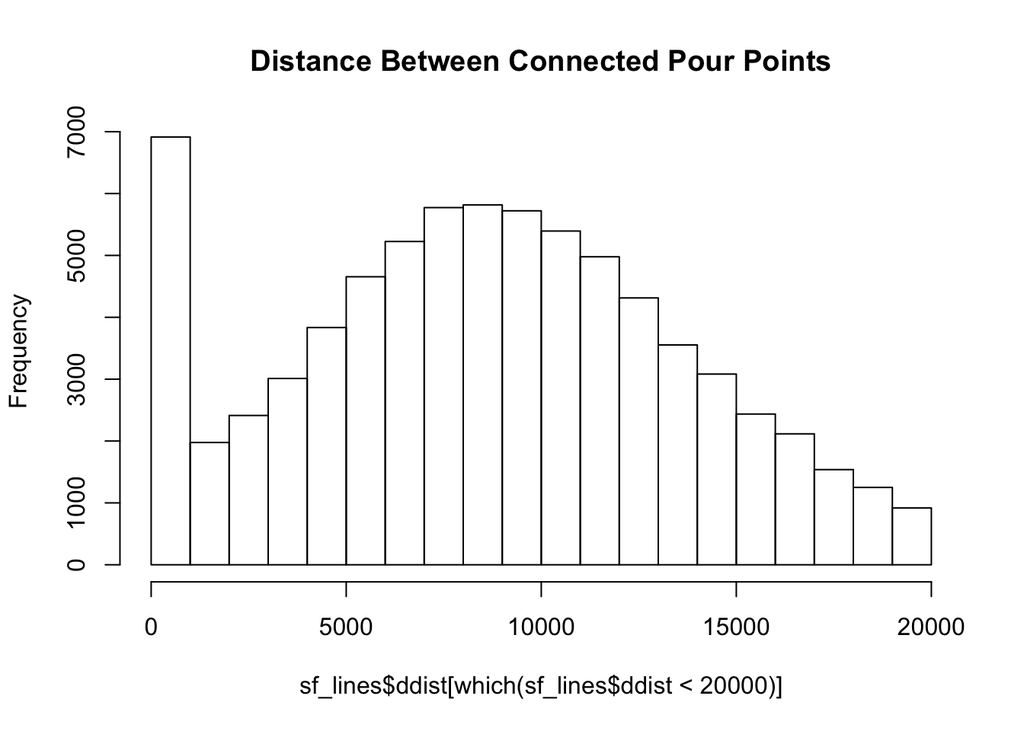

```r
### First step, create lines and distance attribute
fg_lines <- fg_to_lines(fpp_base_ds, fpp_base, "huc_lines.shp", crs = sf::st_crs(fpp))
fg <- fg_lines$fg
sf_lines <- fg_lines$sf_lines
hist(sf_lines$ddist[which(sf_lines$ddist < 20000)], main = "Distance Between Connected Pour Points")
```

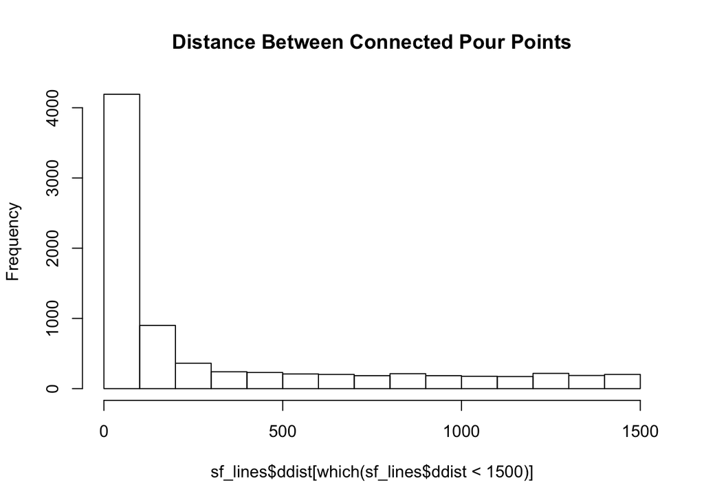

```r
hist(sf_lines$ddist[which(sf_lines$ddist < 1500)], main = "Distance Between Connected Pour Points")
```

Choosing 1000m as the theshold, we can collapse the HU_12_DS such that all fpps with a downstream distance less than 1000m are directed to the next downstream HU_12_DS. Note that this creates `huc_lines_1.shp` which an be used to visualize this result.

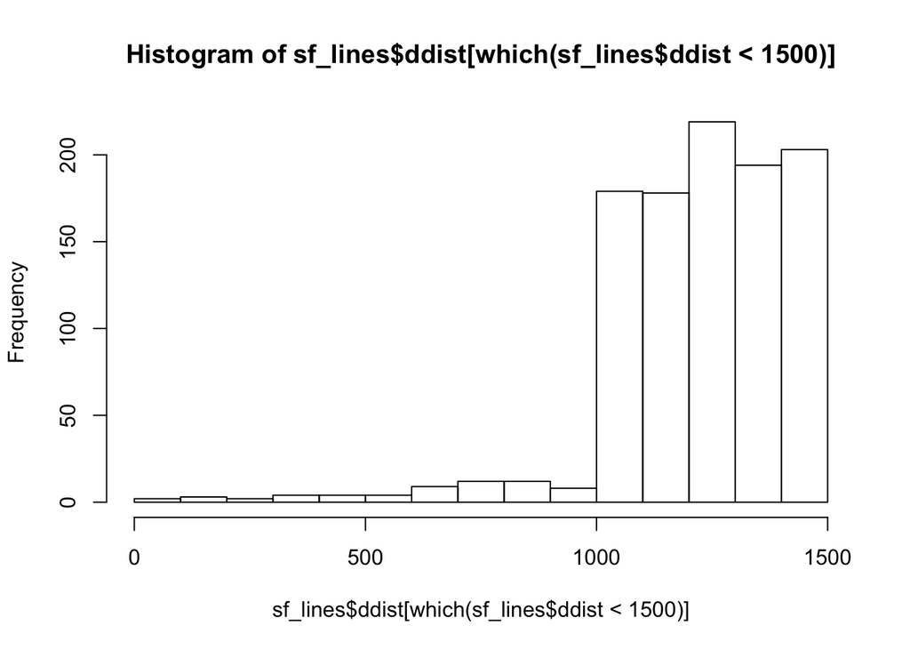

```r
### Set Nexus Threshold
nexus_thresh <- 1000
# Note the large spike below 1000m eliminate them by pointing to next downstream
fg <- collapse_fpp(fg, fpp_base, nexus_thresh)
fg_lines <- fg_to_lines(fg, fpp_base, "huc_lines_1.shp", crs = sf::st_crs(fpp))
fg <- fg_lines$fg
sf_lines <- fg_lines$sf_lines

hist(sf_lines$ddist[which(sf_lines$ddist < 1500)])
```

As we can see this didn’t actually eliminate all of them. That is because of cases like this:

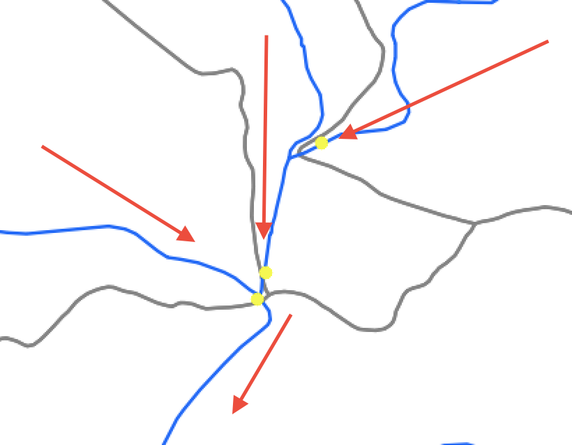

If we run the collapse routine once more, we can eliminate these chained cases. Note that this creates `huc_lines_2.shp` which can be used to visualize the result.

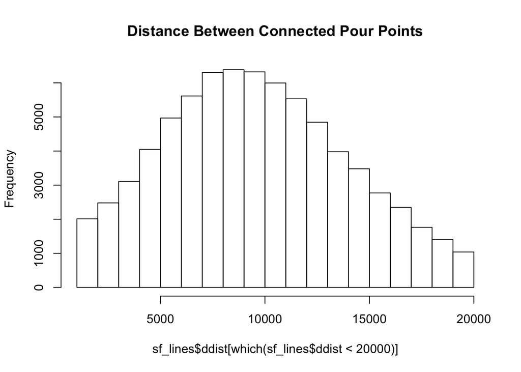

```r
# There were a few chains of very short lines. collapse again to eliminate.
fg <- collapse_fpp(fg, fpp_base, nexus_thresh)
fg_lines <- fg_to_lines(fg, fpp_base, "huc_lines_2.shp", crs = sf::st_crs(fpp))
fg <- fg_lines$fg
sf_lines <- fg_lines$sf_lines

write.csv(fg[c("HUC_12", "HU_12_DS")], "updated_HU_12_DS.csv", quote = T, row.names = F)

hist(sf_lines$ddist[which(sf_lines$ddist < 20000)], main = "Distance Between Connected Pour Points")
```

So now we have HU_12_DS routing that eliminates the case 2 HU combinations, converting the coding to case 1 style even though the geometry still more or less implies case 2 routing. This leaves us with a lot of case 3 HUs where the shortest distance from inflow fpp to outflow fpp is 1000m.

Note that even at 1000m, there are watersheds that may still be considered case 2. The short connection in this example is about 1000m and looks like it could be considered for adjustment.

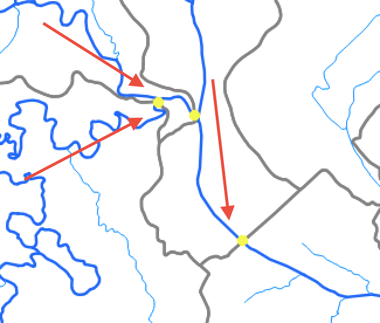

For case 3, we need to take a different approach. HY_Features has the concept of a “conjoint” catchment. The original intent for “conjoint” catchments was cases where two or more rivers flow into an area of complex channels or a marsh such that delineation of seperate catchments is unrealistic, but there should theoretically be more than one catchment present. We can use this concept for the case 3 HUs. That is, any HU that has multiple inflows is, in fact, more than one catchment with unknown internal boundaries. In an ideal world, we would delineate those internal boundaries, splitting the HU up into sub catchments, but first, lets just find them so we can see them on a map.

The code below figures out which HU12s have multiple inflows and generates a row for each pair of contributing fpps. So, for a HU12 that has three contributing fpps (a, b, and c) we end up with rows for (ab, ac, and bc). We’ll use these pairs later on. The second block pars down these pairs and throws away data we could use later, generating a simple table that sais whether each HU12 is conjoint or catchment. Note that the `distance==max(distance)` filter is just a convenient way to get one row for each conjoint HU12 and the `distance > nexus_thresh` eliminates HU12s that are in case 1. Note that the set we are considering here has instances of case 2 removed already.

```r
# finds all HU_12_DS's with many HUC_12 contributors.
# Builds all combinations of FPPs that contribute to each HU_12_DS
# Adds X/Y for each row's points.
fpp_pairs <- select(fg, -ddist) %>%
  group_by(HU_12_DS) %>%
  summarise(NUM_CONTRIBUTING = n()) %>%
  filter(NUM_CONTRIBUTING > 1) %>%
  left_join(select(fg, -ddist), by = "HU_12_DS") %>%
  select(-NUM_CONTRIBUTING) %>%
  group_by(HU_12_DS) %>%
  do(data.frame(t(combn(.$HUC_12, 2)), stringsAsFactors = F)) %>% # fancy!
  rename(h1 = X1, h2 = X2) %>%
  left_join(fpp_base, by = c("h1" = "HUC_12")) %>%
  rename(X1 = X, Y1 = Y) %>%
  left_join(fpp_base, by = c("h2" = "HUC_12")) %>%
  rename(X2 = X, Y2 = Y) %>%
  mutate(distance = dist_fun(X1, Y1, X2, Y2))

# Find hucs with pairs who's max distance is greater than the nexus threshold.
conjoint <- group_by(fpp_pairs, HU_12_DS) %>%
  filter(distance == max(distance) & distance > nexus_thresh) %>%
  ungroup() %>%
  select(HUC_12 = HU_12_DS) %>%
  mutate(conjoint = "conjoint") %>%
  right_join(select(hu_atts, HUC12), by = c("HUC_12" = "HUC12")) %>%
  mutate(conjoint = ifelse(is.na(conjoint), "catchment", "conjoint"))

write.csv(conjoint, "conjoint.csv", row.names = F, quote = T)
```

The following code may be a bit of a stretch, but it’s included for completeness. It really needs to be reworked and used for future work.

Ideally, we would have a representative point for each of the collapsed nexuses we identified while removing case 2 HU combinations. See comments below for details of this code.

`nexus_points.shp` is generated by this code.

```r
### Find nexus locations.
nexus_pairs <- filter(fpp_pairs, distance < nexus_thresh)

# this is dumb but I can't think of a better way to catch potential chains
# Maybe: https://stackoverflow.com/questions/12135971/identify-groups-of-linked-episodes-which-chain-together
# Attempts to identify all the unique pairs that might be part of a single nexus.
# h1 and h2 are pairs of hu fpps that contribute to the same HU12.
nexus_group_seed <- setNames(unique(nexus_pairs$h1), c(1:length(unique(nexus_pairs$h1))))

group_members <- sapply(nexus_group_seed, function(x) {
  # x is the seed, this grabs the obvious h2.
  set <- c(x, nexus_pairs$h2[which(nexus_pairs$h1 %in% x)])
  # this attempts to find chains by searching against all in the set.
  set <- c(set, nexus_pairs$h2[which(nexus_pairs$h1 %in% set)])
  # same as above, but searching all in the set against h2 rather than h1.
  set <- c(set, nexus_pairs$h1[which(nexus_pairs$h2 %in% set)])
  # This results in duplicates, so just return the unique values.
  unique(set)
}) %>% stack() %>% # sapply returns a list, stack turns it into a `data.frame`
  rename(nexus = ind, HUC_12 = values) %>%
  distinct() %>%
  left_join(select(fpp_base_ds, HUC_12, X, Y), by = "HUC_12")

# Group them together and grab the most downstream one and eliminate overlaying ones.
# This is VERY imperfect see what's going on at the outlet of 171001030509.
group_nexuses <- group_by(group_members, nexus) %>%
  arrange(HUC_12) %>%
  filter(HUC_12 == last(HUC_12)) %>% # This doesn't reliably grab the most downstream
  ungroup() %>%
  mutate(nexus = as.integer(nexus), p = (X^2 - Y^2)) %>%
  group_by(p) %>%
  filter(nexus == last(nexus)) %>% # This eliminates collocated ones.
  ungroup() %>%
  select(-HUC_12, -p)

# Figure out which fpps are not included in a nexus for output.
max_nexus <- max(as.numeric(group_nexuses$nexus)) + 1
not_grouped <- fpp$HUC_12[which(!fpp$HUC_12 %in% group_members$HUC_12)]
not_grouped <- data.frame(HUC_12 = not_grouped,
                          nexus = c(max_nexus:(max_nexus + length(not_grouped)-1)),
                          stringsAsFactors = F) %>%
  left_join(fpp_base, by = "HUC_12") %>%
  select(-HUC_12)

# bind it all together and save.
nexus_points <- bind_rows(group_nexuses, not_grouped)
nexus_points <- sf::st_as_sf(nexus_points,
                         coords = c("X", "Y"),
                         crs = sf::st_crs(fpp))

sf::write_sf(nexus_points, "nexus_points.shp")
```